# Clear figures, stronger stories

Scientific workflows: Tools and Tips 🛠️

Dr. Selina Baldauf

2025-04-17

## What is this lecture series?

### Scientific workflows: Tools and Tips 🛠️

📅 Every 3rd Thursday 🕓 4-5 p.m. 📍 Webex

- One topic from the world of scientific workflows
- Material provided [online](https://selinazitrone.github.io/tools_and_tips/)
- If you don’t want to miss a lecture
  - [Subscribe to the mailing list](https://lists.fu-berlin.de/listinfo/toolsAndTips)

## Motivation

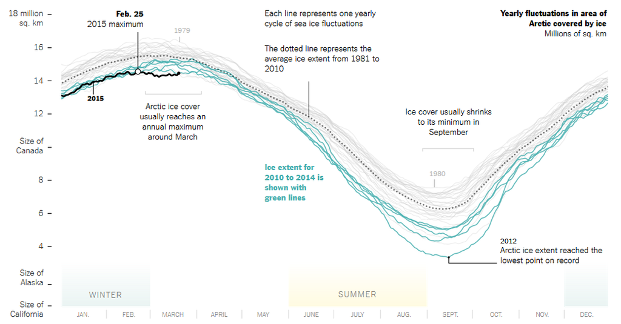

Annual changes in Arctic sea ice cover by [Derek Watkins (New York Times)](https://www.nytimes.com/interactive/2015/03/24/science/earth/arctic-ice-low-winter-maximum.html?_r=0)

## What makes a good figure?

- **Correct and transparent**  
  Truthful representation of the data, data integrity
- **Useful**  
  Supports the main point you want to make
- **Easy to read and understand**  
  Accessible for everyone
- **Beautiful**  
  Visually interesting and pleasing
- **Appropriate**  
  Different outlets have different requirements/freedoms

# 7 steps for better figures

# 👣 1: Consider the context

## Consider the context

- **Who** is your **audience**?  
  Familiarity with the topic
- **What** are **common practices** in your field?  
  Established plot types, colors, …
- **Where** do you present your figure?  
  Different contexts require different designs

## Contexts in science

| Context | Things to consider |
| --- | --- |
| Paper | - Journal requirements - Usually read on PC but also print (B/W) - More time → Higher complexity |
| Poster | - More open design choice - Attract people from far - You quickly loose people to other posters - Medium complexity (depending on the event) |
| Talk | - You can use animations to guide through - Little time → less complex |

# 👣 2: Make your data transparent

## Don’t hide data behind summaries

[figure not shown]

## Don’t hide data behind summaries

[figure not shown]

## Don’t hide data behind summaries

Bar graphs hide a lot of information about the data.

[figure not shown]

https://doi.org/10.1371/journal.pbio.1002128

## Don’t hide data behind summaries

Same bar plot - different data & statistical test results

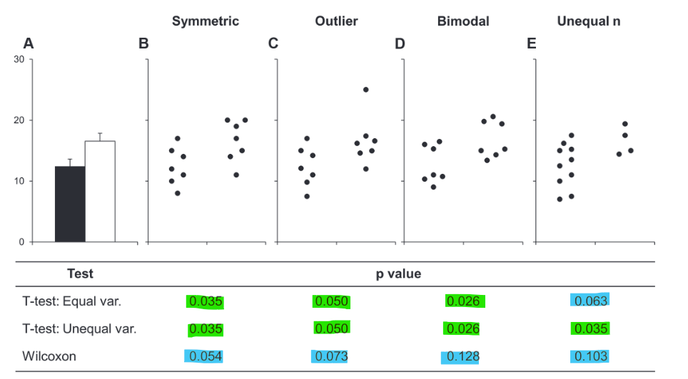

Figure 1 from [Weissgerber et al. 2015](https://doi.org/10.1371/journal.pbio.1002128)

## Alternatives to bar plots

Bar plots only show mean ± SE/SD.

[figure not shown]

## Alternatives to bar plots

A box plot is already better (shows more of the distribution)

[figure not shown]

## Alternatives to bar plots

A box plot is already better (shows more of the distribution)

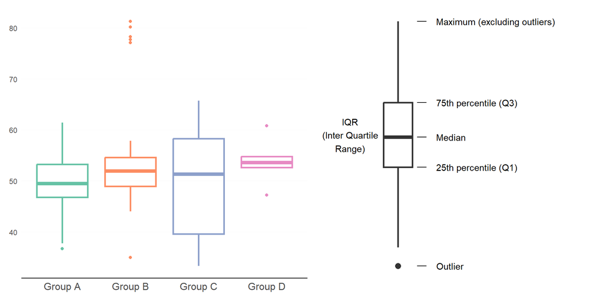

## Alternatives to bar plots

Add raw data points to increase the information content of the plot

[figure not shown]

## Alternatives to bar plots

**Raincloud plots** show raw data, summary stats, and distribution

[figure not shown]

## Principle of proportional ink

**Sizes of shaded areas** should be **proportional** to the **data values** they represent

[figure not shown]

Here: bar length does not represent **relative data proportions** anymore

Always start bars at 0!

Bergstrom and West (2016)

## Principle of proportional ink

Other plot types don’t have to start at 0.

[figure not shown]

# 👣 3: Choose the right chart type

## Choose the right chart type

There are so many chart types - and cool tools to explore them

[figure not shown]

[From data vo viz](https://www.data-to-viz.com/)

[figure not shown]

[The dataviz project](https://datavizproject.com/)

## Different channels - different accuracy

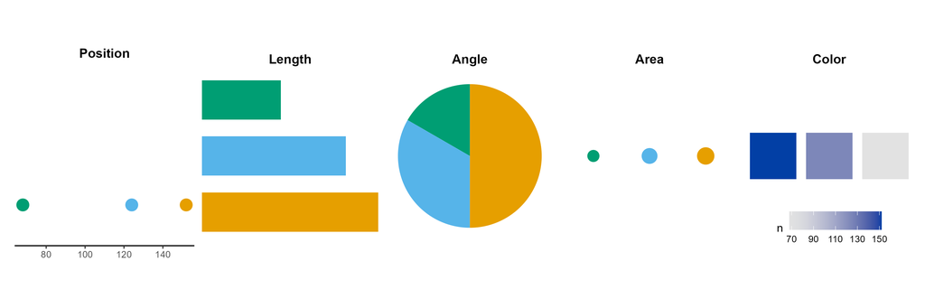

- Accuracy of judgement decreases from left to right
- More accurate judgements vs. more generic judgements

## Different channels - different accuracy

- Combine multiple channels for more accuracy
- Add numbers to increase accuracy of judgement

[figure not shown]

# 👣 4. Focus on the core message

## Focus on the core message

- The readers attention is limited: **be concise**
- Think about the **main message** you want to convey
  - Which variables do you need?
  - What can you omit?

## Arrange your plot

Arrange your plot so that it’s **easy to extract** the main message

[figure not shown]

## Choose a good plot type

Different plot types tell different stories

[figure not shown]

## Keep it simple

**Don’t overcomplicate** your figures and bury your message

What is the main message here?

[figure not shown]

## Keep it simple

Message: Life expectancy and GDP differences in the world

[figure not shown]

# 👣 5. Consider the trip

## Reading a figure is a timely experience

- We look at elements **step by step** before we come back to understand the **figure as a whole**
- Put yourself in the readers shoes
  - What will they look at first, second, etc.?
  - **How many steps** does it take to understand all the elements?

**Goal**: Make the trip (for the eyes and the brain) as short as possible

## Consider the trip

A story about the GDP China and India

[figure not shown]

## Rotate your plot

Reading labels upside down is a neck rotation - very annoying

[figure not shown]

## Highlight the main message

Use highlighting and de-emphasizing

- Make use of **pre-attentive focus** (Things that *pop* out)
- Possible highlights: color, size, shape, arrows, …

## Highlight the main message

Highlight focus contries, de-emphasize all others

[figure not shown]

## Highlight the main message

Highlight focus contries, de-emphasize all others

[figure not shown]

## Order your data

Order categories consciously not automatically.

[figure not shown]

## Order your data

Order categories consciously not automatically.

[figure not shown]

# 👣 6. Less is more

## The importance of differences

Use differences to **communicate not to decorate**

[figure not shown]

## Declutter your figure

- Try to maximize the **data/ink ratio**
- This is to an extent a matter of taste
- Remove redundant figure elements  
  Excessive grid lines, boxes, duplicate text …
- But keep elements important for reading

## Declutter your graphs

[figure not shown]

# 👣 7: Make it accessible

## Element size

- Make sure your elements are big enough  
  Text size, Linewidth, Point size
- Depends on the context

[figure not shown]

## Contrast

Make sure that the contrast is high enough

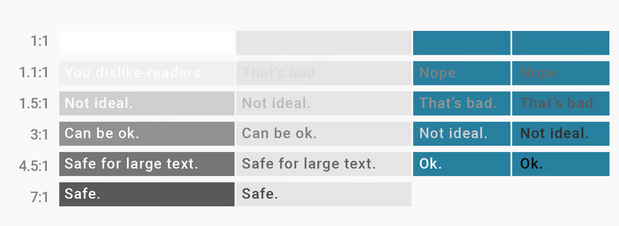

[Blogpost on colors](https://www.datawrapper.de/blog/colors) by Lisa Charlotte Muth (Datawrapper)

- Use tools to check contrast, e.g.  
  https://snook.ca/technical/colour_contrast

## Color

Use logical/intuitive colors

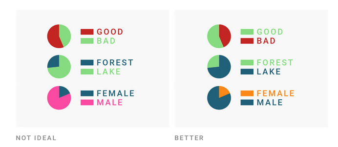

[Blogpost on colors](https://www.datawrapper.de/blog/colors) by Lisa Charlotte Muth (Datawrapper)

## Color

Choose colorblind friendly palettes (if in doubt: test!).

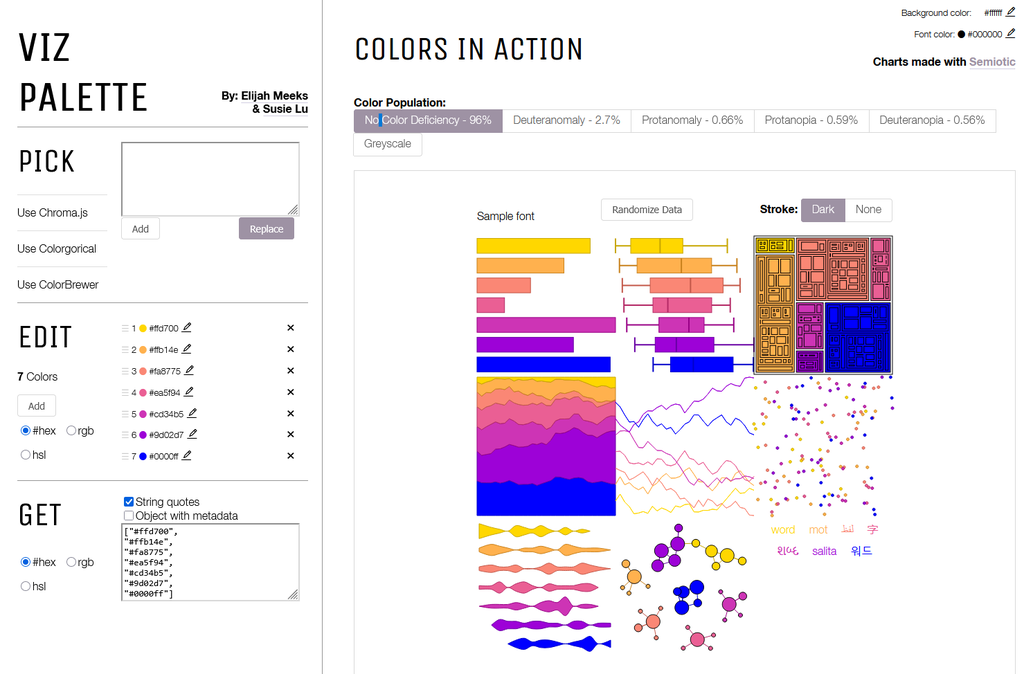

Use the [Viz Palette tool](https://projects.susielu.com/viz-palette) to test for color blindness

## Add redundancy

Redundancy increases the chance that everyone can see the difference!

[figure not shown]

## Summary

1. Consider the **context**
2. Make your data **transparent**
3. Choose the **right chart type**
4. Focus on the **core message**
5. Consider the **trip**
6. **Less is more**
7. Make it **accessible**

Start analyzing these points in yours and other people’s plots.

## Next lecture

#### Topic t.b.a.

🔔 [Subscribe to the mailing list](https://lists.fu-berlin.de/listinfo/toolsAndTips)

📧 For topic suggestions and/or feedback send me an email

## Thank you for your attention :)

Questions?

## References

[figure not shown]

[Healy, K. (2018). Data Visualization: A Practical Introduction. Princeton University Press.](https://socviz.co/index.html#preface)

[figure not shown]

[Wilke, C. O. (2019). Fundamentals of Data Visualization. O’Reilly Media.](https://clauswilke.com/dataviz/)